# Data Science Workflows

## <a href="https://github.com/chendaniely/biovis_jp_workflow" class="uri">https://github.com/chendaniely/biovis_jp_workflow</a>

### Daniel Chen (<span class="citation">@chendaniely</span>)

こんにちは!

# I'm Daniel

[figure not shown]

- PhD Student: Virginia Tech
- Data Enginner: University of Virginia
- Instructor: DataCamp, The Carpentries
- Data Scientist: Lander Analytics
- Member: Meetup (DataCommunity DC)
- Event Photographer
- SCUBA Diver (Cavern, Divemaster)
- Snowboarder
- Author:

[figure not shown]

# ありがとう

[figure not shown]

# Structuring Your Data Science Projects

We are happy when our code just runs

R has given us the tools to make your projects more structured and organized

Many people converge on very similar project templates

It doesn't matter where you are in your learning path

## tl;dr

> I just want stuff to run the first time around

# Tidy Data Paper -- Billboard Dataset

- [Tidy data paper](http://vita.had.co.nz/papers/tidy-data.html)
- Billboard dataset
- [Github repository](https://github.com/hadley/tidy-data/tree/master/data) has "original" and "cleaned" data

# tl;dr

1. Use R
2. Make a project
3. Organize the project into folders and use `here::here()` to get project relative paths
4. Break up scripts into smaller pieces
5. RMarkdown for things you want to show
6. Put functions in `R` so your analysis is package ready and write `Makefiles`, shell scripts, or other build scripts and link your projects to scholarship so your figures and tables are always up to date

[figure not shown]

# Package management

- Packrat (https://rstudio.github.io/packrat/)
- Checkpoint (https://cran.r-project.org/web/packages/checkpoint/index.html)
- conda (https://conda.io/docs/commands.html#conda-environment-commands)

# (More) Resources

- slide template: [xaringan](https://github.com/yihui/xaringan) ([remark.js](https://github.com/gnab/remark))
- [Jenny Bryan - Stop working directory insanity](https://gist.github.com/jennybc/362f52446fe1ebc4c49f)
- [Jenny Bryan - Naming things](https://speakerdeck.com/jennybc/how-to-name-files)
- [John Myles White - ProjectTemplate](http://projecttemplate.net/)
- [John Blischak - workflowr: organized + reproducible + shareable data science in R](https://jdblischak.github.io/workflowr/)
- [rr-init](https://github.com/Reproducible-Science-Curriculum/rr-init)
- [Compuational Project  Cookie Cutter](https://github.com/chendaniely/computational-project-cookie-cutter)

# Thanks!

[github](https://github.com/chendaniely)/[twitter](https://twitter.com/chendaniely)/[instagram](https://www.instagram.com/chendaniely/)/gmail: `@chendaniely`

https://github.com/chendaniely/biovis_jp_workflow

[#rdogladies](https://twitter.com/hashtag/rdogladies)

[#hobbestheblueheelermix](https://www.instagram.com/explore/tags/hobbestheblueheelermix/)

[figure not shown]

Backup Slides for reference.

# A Tale of Two Dialects

[figure not shown]

# Clean Data (Original)

```r
library(stringr)
library(plyr)

rm(list = ls())
setwd('~/git/hub/rstatsdc_2018-structure/01-just_starting_out/')

raw <- read.csv("billboard.csv")

raw <- raw[, c("year", "artist.inverted", "track", "time", "date.entered", "x1st.week",
*              "x2nd.week", "x3rd.week", "x4th.week", "x5th.week", "x6th.week", "x7th.week", "x8th.week", "x9th.week", "x10th.week", "x11th.week", "x12th.week", "x13th.week", "x14th.week", "x15th.week", "x16th.week", "x17th.week", "x18th.week", "x19th.week", "x20th.week", "x21st.week", "x22nd.week", "x23rd.week", "x24th.week", "x25th.week", "x26th.week", "x27th.week", "x28th.week", "x29th.week", "x30th.week", "x31st.week", "x32nd.week", "x33rd.week", "x34th.week", "x35th.week", "x36th.week", "x37th.week", "x38th.week", "x39th.week", "x40th.week", "x41st.week", "x42nd.week", "x43rd.week", "x44th.week", "x45th.week", "x46th.week", "x47th.week", "x48th.week", "x49th.week", "x50th.week", "x51st.week", "x52nd.week", "x53rd.week", "x54th.week", "x55th.week", "x56th.week", "x57th.week", "x58th.week", "x59th.week", "x60th.week", "x61st.week", "x62nd.week", "x63rd.week", "x64th.week", "x65th.week", "x66th.week", "x67th.week", "x68th.week", "x69th.week", "x70th.week", "x71st.week", "x72nd.week", "x73rd.week", "x74th.week", "x75th.week",
*              "x76th.week")]
names(raw)[2] <- "artist"

raw$artist <- iconv(raw$artist, "MAC", "ASCII//translit")
raw$track <- stringr::str_replace(raw$track, " \\(.*?\\)", "")
names(raw)[-(1:5)] <- str_c("wk", 1:76)
raw <- plyr::arrange(raw, year, artist, track)

long_name <- nchar(raw$track) > 20
raw$track[long_name] <- paste0(substr(raw$track[long_name], 0, 20), "...")
```

# Clean Data

```
##   year       artist                   track time date.entered wk1 wk2 wk3
## 1 2000        2 Pac          Baby Don't Cry 4:22   2000-02-26  87  82  72
## 2 2000      2Ge+her The Hardest Part Of ... 3:15   2000-09-02  91  87  92
## 3 2000 3 Doors Down              Kryptonite 3:53   2000-04-08  81  70  68
## 4 2000 3 Doors Down                   Loser 4:24   2000-10-21  76  76  72
## 5 2000     504 Boyz           Wobble Wobble 3:35   2000-04-15  57  34  25
## 6 2000      A*Teens           Dancing Queen 3:44   2000-07-08  97  97  96
##   wk4 wk5 wk6 wk7 wk8 wk9 wk10 wk11 wk12 wk13 wk14 wk15 wk16 wk17 wk18
## 1  77  87  94  99  NA  NA   NA   NA   NA   NA   NA   NA   NA   NA   NA
## 2  NA  NA  NA  NA  NA  NA   NA   NA   NA   NA   NA   NA   NA   NA   NA
## 3  67  66  57  54  53  51   51   51   51   47   44   38   28   22   18
## 4  69  67  65  55  59  62   61   61   59   61   66   72   76   75   67
## 5  17  17  31  36  49  53   57   64   70   75   76   78   85   92   96
## 6  95 100  NA  NA  NA  NA   NA   NA   NA   NA   NA   NA   NA   NA   NA
##   wk19 wk20 wk21 wk22 wk23 wk24 wk25 wk26 wk27 wk28 wk29 wk30 wk31 wk32
```

[output cut: 34 more lines]

# Clean Data (Tidyverse)

```r
library(readr)
library(dplyr)
library(stringr)

rm(list = ls())
setwd('~/git/hub/rstatsdc_2018-structure/01-just_starting_out/')

(raw <- readr::read_csv('billboard.csv') %>%
    dplyr::select(year, artist.inverted, track, time, date.entered,
*                 x1st.week:x76th.week) %>%
    dplyr::rename(artist = artist.inverted) %>%
    dplyr::mutate(artist = iconv(artist, "MAC", "ASCII//translit")) %>%
    dplyr::mutate(track = stringr::str_replace(track,  " \\(.*?\\)", "")) %>%
    dplyr::arrange(year, artist, track) %>%
    dplyr::mutate(track = dplyr::case_when(
        nchar(track) > 20 ~ stringr::str_c(stringr::str_sub(track, 0, 20), "..."),
        TRUE ~ track
    ))
)
(names(raw)[-(1:5)] <- str_c("wk", 1:76)) # changed the order here
```

# Clean Data

```
## # A tibble: 317 x 81
##     year artist track time  date.entered   wk1   wk2   wk3   wk4   wk5
##    <int> <chr>  <chr> <tim> <date>       <int> <int> <int> <int> <int>
##  1  2000 2 Pac  Baby… 04:22 2000-02-26      87    82    72    77    87
##  2  2000 2Ge+h… The … 03:15 2000-09-02      91    87    92    NA    NA
##  3  2000 3 Doo… Kryp… 03:53 2000-04-08      81    70    68    67    66
##  4  2000 3 Doo… Loser 04:24 2000-10-21      76    76    72    69    67
##  5  2000 504 B… Wobb… 03:35 2000-04-15      57    34    25    17    17
##  6  2000 A*Tee… Danc… 03:44 2000-07-08      97    97    96    95   100
##  7  2000 Aaliy… I Do… 04:15 2000-01-29      84    62    51    41    38
##  8  2000 Aaliy… Try … 04:03 2000-03-18      59    53    38    28    21
##  9  2000 Adams… Open… 05:30 2000-08-26      76    76    74    69    68
## 10  2000 Adkin… More  03:05 2000-04-29      84    84    75    73    73
## # ... with 307 more rows, and 71 more variables: wk6 <int>, wk7 <int>,
## #   wk8 <int>, wk9 <int>, wk10 <int>, wk11 <int>, wk12 <int>, wk13 <int>,
## #   wk14 <int>, wk15 <int>, wk16 <int>, wk17 <int>, wk18 <int>,
## #   wk19 <int>, wk20 <int>, wk21 <int>, wk22 <int>, wk23 <int>,
## #   wk24 <int>, wk25 <int>, wk26 <int>, wk27 <int>, wk28 <int>,
## #   wk29 <int>, wk30 <int>, wk31 <int>, wk32 <int>, wk33 <int>,
## #   wk34 <int>, wk35 <int>, wk36 <int>, wk37 <int>, wk38 <int>,
## #   wk39 <int>, wk40 <int>, wk41 <int>, wk42 <int>, wk43 <int>,
## #   wk44 <int>, wk45 <int>, wk46 <int>, wk47 <int>, wk48 <int>,
## #   wk49 <int>, wk50 <int>, wk51 <int>, wk52 <int>, wk53 <int>,
## #   wk54 <int>, wk55 <int>, wk56 <int>, wk57 <int>, wk58 <int>,
## #   wk59 <int>, wk60 <int>, wk61 <int>, wk62 <int>, wk63 <int>,
## #   wk64 <int>, wk65 <int>, wk66 <chr>, wk67 <chr>, wk68 <chr>,
## #   wk69 <chr>, wk70 <chr>, wk71 <chr>, wk72 <chr>, wk73 <chr>,
## #   wk74 <chr>, wk75 <chr>, wk76 <chr>
```

# Tidy

```r
clean_out <- raw %>%
    tidyr::gather(key = 'week', value = "value", # can rename rank = value here
              tidyselect::matches('^wk')) %>%
    dplyr::mutate(week = as.integer(stringr::str_replace_all(week, "[^0-9]+", "")),
                  date.entered = lubridate::ymd(date.entered),
                  date = date.entered + lubridate::weeks(week - 1)
                  ) %>%
    dplyr::select(-date.entered) %>%
    dplyr::rename('rank' = 'value') %>%
    dplyr::arrange(year, artist, track, time, week) %>%
    dplyr::select(year, artist, time, track, date, week, rank)
```

# EDA

```r
clean_out$month <- lubridate::month(clean_out$date)

# average rank by week
wk_rnk_avg <- clean_out %>%
    dplyr::group_by(week) %>%
    dplyr::summarise(avg_rnk = mean(rank))
```

# EDA Vis

```r
library(ggplot2)
ggplot2::ggplot(wk_rnk_avg, ggplot2::aes(x = week, y = avg_rnk)) +
    ggplot2::geom_line() +
    ggplot2::geom_vline(aes(xintercept = 52), color = 'red') +
    ggplot2::ggtitle(label = 'Average Rank Across All Songs by Week',
                     subtitle = 'Red line shows 52 weeks (1 Year)') +
    ggplot2::xlab('Week') +
    ggplot2::ylab('Average rank')
```

# EDA Vis

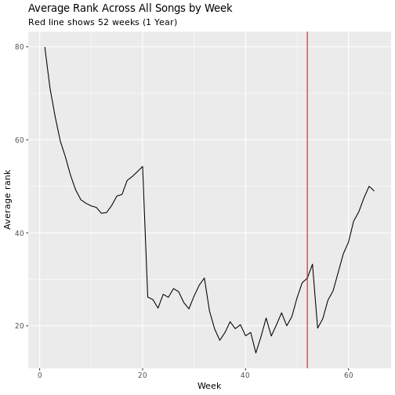

# Model

```r
fit <- lm(rank ~ week + artist, data = clean_out)
coefs <- broom::tidy(fit)
coefs
```

```
## # A tibble: 228 x 5
##    term                      estimate std.error statistic  p.value
##    <chr>                        <dbl>     <dbl>     <dbl>    <dbl>
##  1 (Intercept)                 87.6      7.69      11.4   1.02e-29
##  2 week                        -0.542    0.0368   -14.7   4.66e-48
##  3 artist2Ge+her                3.49    14.0        0.249 8.04e- 1
##  4 artist3 Doors Down         -37.8      8.07      -4.68  2.90e- 6
##  5 artist504 Boyz             -26.2      9.06      -2.89  3.81e- 3
##  6 artistA*Teens               11.0     11.9        0.926 3.54e- 1
##  7 artistAaliyah              -49.6      8.20      -6.06  1.49e- 9
##  8 artistAdams, Yolanda       -14.2      8.93      -1.58  1.13e- 1
##  9 artistAdkins, Trace         -8.07     9.83      -0.821 4.12e- 1
## 10 artistAguilera, Christina  -60.2      8.08      -7.44  1.14e-13
## # ... with 218 more rows
```

# Vis Model

```r
library(forcats)

ggplot(coefs[!coefs$term %in% c('(Intercept)'), ],
       aes(x = estimate,
           y = forcats::fct_reorder(term, estimate))) +
    geom_point() +
    theme_minimal()
```

# Vis Model

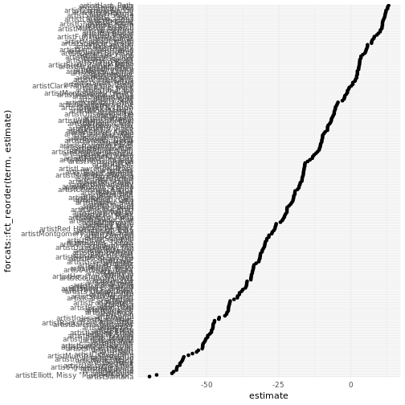

Demo 01

# Do you want your computer set on fire...?

... because that's how you get your computer set on fire.

[figure not shown]

# What's wrong with `setwd()`?

- **You are assuming a folder structure**
    - Your collaborator might not have the same structure
    - Your other computer might not have the same structure
    - You want to move files and folders around and now... you guessed it, don't have the same structure!

- You end up having a different line in your code for every possible location and commenting it in and out
    - Annoying for yourself, others, and
    - Version control systems

# Make a Project

[figure not shown]

```bash
diff -r 01-just_starting_out 02-projects | grep "Only in 02-projects"
```

```
## Only in 02-projects: 02-projects.Rproj
```

# RStudio projects assume everyone is using RStudio

```r
TRUE
```

```
## [1] TRUE
```

#### but...

- [Emacs ESS](https://ess.r-project.org/) allows you to pick the working directory
- `cd` in linux changes the working directory
    - Run code from working directory

# What's wrong with `rm(list = ls())`?

- **It doesn't detatch libraries**
    - You might end up using a function without an explicit `library` call in your script

## What do I do instead?

1. RStudio: Session > Restart R (Ctrl + Shift + F10)
2. Terminal: `Rscript myscript.R`

Demo 02

# Am I done yet? Yes, but...

[figure not shown]

# `project += structure`

Yes this is the whole point of this talk...

[figure not shown]

# Noble's recommendations

[figure not shown]

# What I/we do

[figure not shown]

# But basically...

1. **Data** (e.g., `data`)
    1. `orginal` folder from your original (read-only) data
    2. `processed` folder that your scripts create
        - If you want you can break down `processed` to `intermediate` and/or `final`
        - Do whatever feels right
    - Create symbolic links (i.e., shortcuts) as needed if you are using a version control system.
2. **Code** (e.g., `src`, `analysis`)
    - Same thing as the data folder: create subfolders as necessary
3. **Output** (e.g., `output`, `plots`, `results`)<sup>1</sup>
    1. Things your script outputs that is not a dataset
    2. `git` does not track empty folders, so put in a `README.md` or `.gitkeep` file
4. **Functions** (e.g., `R`)
5. **README** files

Make sub-folders as needed, everything is in a project and/or has a fixed working directory.

Demo 03

# Can we do better? Of course.

#### How long is my script?

```bash
wc 01-just_starting_out/analysis.R
```

```
##  171  682 6348 01-just_starting_out/analysis.R
```

#### What does my script do?

1. Loads
2. Cleans
3. Tidy
4. Normalize
5. EDA
6. Model

# Split it up into separate scripts ... in a subfolder

1. Loads
2. Cleans
3. Tidy
4. Normalize
5. EDA
6. Model

1. `01-load.R`
2. `02-01-clean.R`
3. `02-02-tidy.R`
4. `02-03-normalize.R`
5. `03-eda.R`
6. `04-model.R`

Be sensible, a 2 line script is probably not worth it, but a 2000 line script is unwieldy.

Demo 04

# What else?

[Rachael Tatman](http://www.rctatman.com/) (from [Kaggle](https://www.kaggle.com/)) [@rctatman](https://twitter.com/rctatman)

- [R-Ladies](https://rladies.org/) organizer ([Seattle chapter](https://www.meetup.com/rladies-seattle/))
- Data scientist at Kaggle
- [RLadies DC Meetup](https://www.meetup.com/rladies-dc/): [Put together a data science portfolio](https://www.meetup.com/rladies-dc/events/254015586/)
    - http://www.rctatman.com/files/Tatman_2018_DataSciencePortfolios_DC.pdf

[figure not shown]

# Knitr

1. Loads
2. Cleans
3. Tidy
4. Normalize
5. EDA
6. Model

1. `01-load.R`
2. `02-01-clean.R`
3. `02-02-tidy.R`
4. `02-03-normalize.R`
5. `03-eda.Rmd`
6. `04-model.Rmd`

# But...

- Sometimes working with knitr in RStudio projects get weird because of working directories <sub>[1]</sub>
- I don't work in RStudio

## Fix this with the `here` [package](https://here.r-lib.org/)

- It's based off [rprojroot](https://rprojroot.r-lib.org/)

In `here::here()`:
- Is a file named .here present?
- Is this an RStudio Project? Literally, can I find a file named something like foo.Rproj?
- Is this an R package? Does it have a DESCRIPTION file?
- Is this a remake project? Does it have a file named remake.yml?
- Is this a projectile project? Does it have a file named .projectile?
- Is this a checkout from a version control system? Does it have a directory named .git or .svn? - Currently, only Git and Subversion are supported.

Demo 05

# Functions

Not shown in this example

#### But...

1. Put them in an `R` folder for easy reference and `source`ing.
2. Get's the analysis project ready to turn into an [R package](http://r-pkgs.had.co.nz/)

# What about scholarship/formal reports (LaTeX)?

1. Sibbling project

```bash
\begin{figure}[H]
    \centering
*   \includegraphics[width=.7\linewidth]{../06-make/output/billboard_rank_plots/avg_rank_by_week_across_months}
\end{figure}
```

2. Child project ([git submodules](https://git-scm.com/book/en/v2/Git-Tools-Submodules)?)
  - Symbolic links (i.e., shortcuts) could work too

```bash
ln -s ~/git/hub/rstatsdc_2018-structure/06-make .
```

```bash
\begin{figure}[H]
    \centering
*   \includegraphics[width=.7\linewidth]{./06-make/output/billboard_rank_plots/avg_rank_by_week_across_months}
\end{figure}
```

# `knitr` button puts output in the source file location

The output document is put in the `analysis` folder.
I want it in the `output` folder!

#### Solution

use `rmarkdown::render()`

```r
# not executed during build
rmarkdown::render(here::here('./analysis/billboard_eda/03-eda.Rmd'),
*                 output_dir = './output/billboard_reports')
```

# Too many commands to run!

1. Shell Script
2. Make
3. RStudio > Build (?)

# Makefile

```
BILLBOARD=./analysis/billboard_eda/

all : commands

## commands      : show all commands.
commands :
	@grep -E '^##' Makefile | sed -e 's/## //g'

## billboard_eda  : re-generate billboard eda analsyis
billboard_eda :
	Rscript ${BILLBOARD}/01*
	Rscript ${BILLBOARD}/02-01*
	Rscript ${BILLBOARD}/02-02*
	Rscript ${BILLBOARD}/02-03*
	Rscript -e "rmarkdown::render(here::here('./analysis/billboard_eda/03-eda.Rmd'), output_dir = './output/billboard_reports')"
	Rscript -e "rmarkdown::render(here::here('./analysis/billboard_eda/04-model.Rmd'), output_dir = './output/billboard_reports')"

## clean         : clean up junk files.
clean :
	find data/processed/ -type f -name '*.csv' | xargs rm
	find analysis/ type f -name '*.html' | xargs rm
```

Demo 06